# HW8

Sagar Jain

30 March 2020

### Exercise 2

Look at the API documentation at https://dev.socrata.com/foundry/healthdata.nj.gov/9hse-wixk.

#### Part a)

##### *Question:*

Write a function that will use the API and then generate a plot of the rate of heart disease over time by year. Set the default to all races, but include an option to specify the race. To get ggplot2 to generate a plot from within a function, wrap the nal object in the print() function. Be sure to include in your RMarkdown a plot generated by your function, using the default of all races and another using one specific race.

##### *Answer:*

First, I get the table from the url, and take a look at its structure.

```r
url <- "https://healthdata.nj.gov/resource/5dpz-3wxj.json"

heart_disease <- jsonlite::fromJSON(url)

head(heart_disease)
```

| year | race | heartdisease |
| --- | --- | --- |
| 2010 | Black | 151.5 |
| 2010 | Hispanic | 84.8 |
| 2010 | Asian | 66.7 |
| 2010 | All | 126.2 |
| 2010 | White | 129.2 |
| 2011 | Black | 145.2 |

```r
heart_disease_by_year <-function(race_selected = "All")
{
  url <- "https://healthdata.nj.gov/resource/5dpz-3wxj.json"

  heart_disease <- jsonlite::fromJSON(url)

  heart_disease.clean <- heart_disease %>%
    mutate(heartdisease = as.numeric(heartdisease)) %>%
    mutate(year = as.numeric(year))

  heart_disease.plot <- heart_disease.clean  %>%
    subset(!is.na(heartdisease)) %>%
    filter(race == race_selected)

  min_plot <- min(heart_disease.plot$heartdisease)
  max_plot <- max(heart_disease.plot$heartdisease)

  heart_disease.plot <- heart_disease.clean  %>%
    subset(!is.na(heartdisease)) %>%
    filter(year != "Target") %>%
    filter(race == race_selected)

  heart_disease.target <- heart_disease  %>%
    subset(!is.na(heartdisease)) %>%
    filter(year == "Target") %>%
    filter(race == race_selected)

  heart_disease.target <- heart_disease.target$heartdisease %>% as.numeric()

  print(heart_disease.plot)

  ggplot(heart_disease.plot, aes(year, heartdisease)) +
    geom_point() +
    geom_smooth() +
    ylim(min_plot, max_plot) +
    ggtitle(paste("Heart Disease vs Year. Race selection:", race_selected)) +
    geom_hline(yintercept = heart_disease.target, color = "red") +
    xlab("Year") +
    ylab("Heart Disease")
}
```

When the function is ready, I called it for some races to show how it works

```r
heart_disease_by_year()
```

```
##   year race heartdisease
## 1 2010  All        126.2
## 2 2011  All        120.0
## 3 2012  All        116.1
## 4 2013  All        113.0
## 5 2014  All        107.3
## 6 2015  All        103.8
## 7 2016  All        100.2
## 8 2017  All         99.0
```

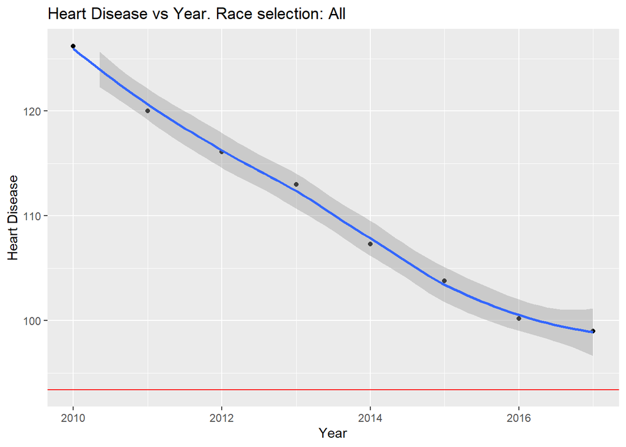

```r
heart_disease_by_year("Hispanic")
```

```
##   year     race heartdisease
## 1 2010 Hispanic         84.8
## 2 2011 Hispanic         76.8
## 3 2012 Hispanic         69.6
## 4 2013 Hispanic         72.7
## 5 2014 Hispanic         66.9
## 6 2015 Hispanic         65.3
## 7 2016 Hispanic         62.3
## 8 2017 Hispanic         64.4
```

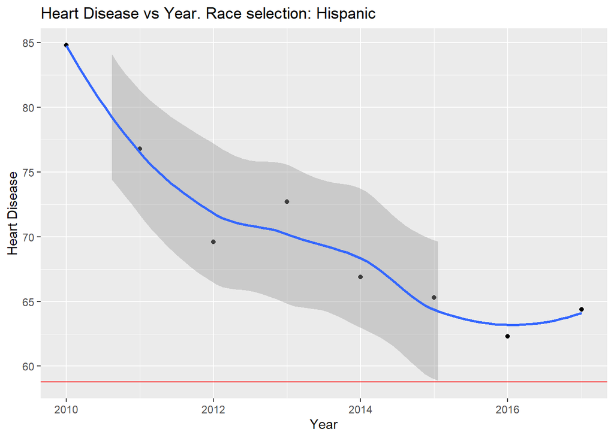